# Experiment 5: Replication Analysis

```r
# Excluding Subjects (AJ: why/how? I can't figure it out, so I'm putting them back in)
# all.data <- all.data %>% filter(subject_id!="603ea6a51c38def3e4140ba6" & subject_id!="5ce1372c55fe0d001869c8d8" & subject_id!="5f47d860b56e68220cb86be1" & subject_id!="607eaf87ac02229ef4fa8f4a" & subject_id!="5d30857eb2f0ad00163470f3" & subject_id!="5e272684f205790453c2c4b8" & subject_id!="5f5b5881b17fa72756b8ff2a" & subject_id!="5fae5291ec402509e2885604")
# E5.excluded.n = 8

#There's an issue with Subject 603ea6a51c38def3e4140ba6: their webgazer_data is a list of length 0 instead of a dataframe like the others.
all.data <- all.data %>% filter(subject_id!="603ea6a51c38def3e4140ba6")


# Convert data to long format for gaze measurements
task.data <- all.data %>%
  filter(response=="a" | response=="d") %>%
  select(subject_id, study_id, time_elapsed, trial_index, response, rt, webgazer_data, webgazer_targets) %>%
  unnest(webgazer_data) %>%
  tidyr::unpack(webgazer_targets) %>%
  tidyr::unpack(c('#face1', '#face2'), names_sep = ".")

# Code condition information
task.data <- task.data %>%
  mutate(task = if_else(study_id == '60748d36577623e2677865c6', "Attractiveness", "Roundness"))

# restrict to time points 1 sd before the decision
rt.summary <- all.data %>%
  filter(response=="a" | response=="d") %>%
  select(subject_id, study_id, trial_index, response, rt) %>%
  summarize(M=mean(rt), SD=sd(rt))
task.data <- task.data %>%
  mutate(time_until_decision = rt - t) %>%
  filter(time_until_decision <= rt.summary$SD)

# Bin in 50 ms bins (not 30 as in the original study, because we are using webcams)
task.data <- task.data %>%
  mutate(time.window = floor(time_until_decision/50)*50+25) #make sure bin is centered
```

Due to large variation in response time latency, Shimojo and colleagues analyzed eye gaze for the 1.67 seconds prior to the response. This duration was one standard deviation of the mean response time, ensuring that all timepoints analyzed have data from at least 67% of trials. In our dataset, one standard deviation amounts to 1.95 seconds. We then binned eyegaze data into 50 ms bins rather than the 30 ms bins used by Shimojo and colleagues, reflecting the different sampling rates.

(ref:groupEMain-caption-separate) Primary results from Exp. 5. The attractiveness judgment along with the best-fitting sigmoid is shown on the *left*. Results for the roundness judgment are shown on the *right*, with the best-fitting sigmoid for the attractiveness judgment depicted in a dashed line for comparison.

(ref:groupEMain-caption) Primary results from Exp. 5. The proportion of fixations to the target in the two seconds prior to the judgment are shown for the attractiveness (red) and roundness (turquoise) conditions along with their best-fitting sigmoids.

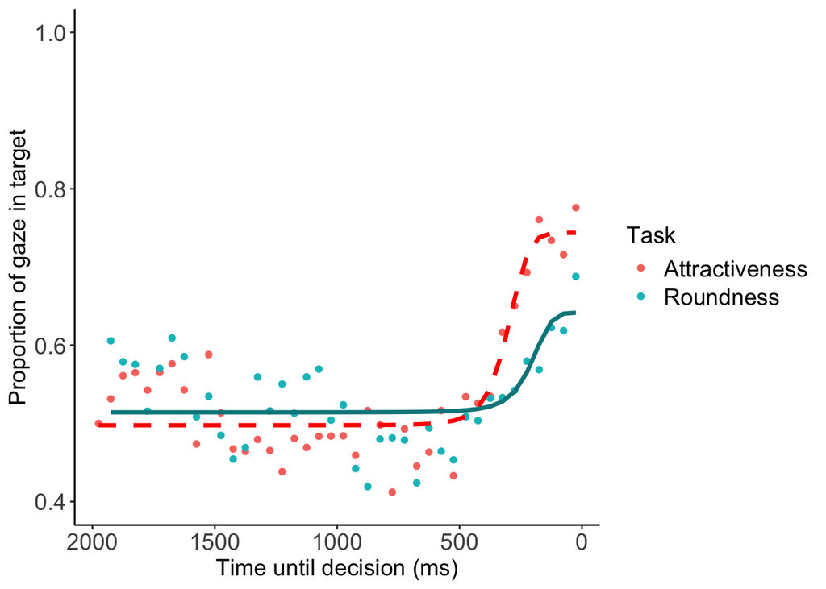

Following Shimojo and colleagues, data for each condition were fit using a four-parameter sigmoid (Fig. @ref(fig:groupEMain)). These fit less well than in the original paper for both the attractiveness judgment (R<sup>2</sup> = 0.8 vs. 0.91) and the roundness judgment (R<sup>2</sup> = 0.36 vs. 0.91).

From these curves, Shimojo and colleagues focus on two qualitative findings. First, they note a higher asymptote for the attractiveness discrimination task relative to roundness discrimination. Qualitatively, this appears to replicate. However, their statistical analysis – a Kolmogorov-Smirnov test for distance between two distributions – is not significant (D = 0.17, p = 0.55), though it should be noted that this is a very indirect statistical test of the hypothesis and probably not very sensitive.

The second qualitative finding they note is that the curve for the roundness judgment “saturates” (asymptotes) earlier than the curve for the attractiveness judgment. They do not present any statistical analyses, but it is clear qualitatively that the result does not replicate.